# Investment Simulation and Environmental Impact Assessment: A Portfolio Analysis of Brown vs. Green Firms

Utilize financial modeling tools and carbon accounting models to simulate investment returns and assess environmental impacts over a five-year period.

Published

October 20, 2021

# 1 Questions:

- What are the uncertainties in this model?
- Should we be using the SCC in this model?
- Maybe probability is accounted for in the model but randomly distributing the allocation of?
- How to incorporate code?
- How do we tie the environmental benefits into this?

```r
library(tidyverse)
library(here)
library(quantmod) #for modeling financial data
library(patchwork)
```

# 2 Define Portfolios

1. Define the date range for the investment model

```r
#define the date range
start_date <- "2014-01-01"
end_date <- "2019-12-31"
```

2. Build portfolios of brown and green firms.

Brown firms include: Exxon Mobil (XOM), Chevron (CVX), BP (BP), ConocoPhillips (COP), and Shell (SHEL).

Green firms include: NextEra Energy (NEE), Tesla (TSLA), Enphase Energy (ENPH), Brookfield Renewable Partners (BEP), and First Solar (FSLR).

```r
# #create vectors based on brown and green tickers
brown_tickers <- c("XOM", "CVX", "BP", "COP", "SHEL")  # Fossil fuel companies
green_tickers <- c("NEE", "TSLA", "ENPH", "BEP", "FSLR")  # Renewable/green tech companies
```

```r
# brown_tickers <- c("XOM", "CVX", "BTU", "RTNTF", "BAYRY")  # Fossil fuel companies
# green_tickers <- c("TSLA", "HGLD", "DNNGY", "BYND","UL")  # Sustainable companies
```

```r
# # #create vectors based on brown and green tickers
# brown_tickers <- c("XOM", "CVX", "BP", "COP", "SHEL", "BTU", "RTNTF", "BAYRY" )  # Fossil fuel companies
# green_tickers <- c("NEE", "TSLA", "ENPH", "BEP", "FSLR", "BYND","HGLD", "UL")  # Renewable/green tech/sustainable companies
```

```r
#get data to build portfolios
#getSymbols = fetches historical stock data for these tickers from Yahoo Finance

for (ticker in brown_tickers) {
  getSymbols(ticker, src = "yahoo", from = start_date, to = end_date)
}

# Fetch data for the Green Portfolio
for (ticker in green_tickers) {
  getSymbols(ticker, src = "yahoo", from = start_date, to = end_date)
}
```

3. Merge the adjusted closing prices for all stocks in each portfolio into individual data frames

**lapply(brown_tickers, function(ticker) Ad(get(ticker))):**

- `lapply()` iterates over each ticker in brown_tickers.
- For each ticker, the function `get(ticker)` retrieves the stock data (including Open, High, Low, Close, Volume, and Adjusted Close prices).
- `Ad()` then extracts just the Adjusted Close price for each stock, creating a list of Adjusted Close prices for each ticker in the brown portfolio.

**do.call(merge, …):**

- `do.call()` applies the merge function across the list of Adjusted Close prices created by `lapply()`.
- merge combines these individual Adjusted Close prices into a single data frame (`brown_prices`) where each column represents one stock’s Adjusted Close price, with dates aligned across all stocks.

Adjusted Closing Prices: An adjusted closing price (ACP) is a modified closing price that takes into account events that impact a stock’s value, such as dividends, stock splits, and rights offerings. The ACP is a more accurate representation of a stock’s value than the closing price, which only shows what investors paid for shares at the end of a trading day. Insight to how the stock has changed over time.

```r
# Combine adjusted closing prices for each portfolio
brown_prices <- do.call(merge, lapply(brown_tickers, function(ticker) Ad(get(ticker))))

green_prices <- do.call(merge, lapply(green_tickers, function(ticker) Ad(get(ticker))))
```

4. Calculate daily returns for each portfolio
- **Daily return =** The calculated daily returns for each stock in the portfolio represent the percentage change in the stock’s price from one day to the next. Each entry in the daily returns data frame shows the percentage change between the Adjusted Close price of one day and the previous day. Insight into daily performance. Daily returns are essential for calculating volatility. Calculates t using the Rate of Change (ROC) function.

```r
brown_returns <- na.omit(ROC(brown_prices, type = "discrete"))
green_returns <- na.omit(ROC(green_prices, type = "discrete"))
```

**Function Definition:** The `ROC()` function calculates the rate of change (returns) between the current price and the previous price in a time series.

**Parameters:**

- **Input:** The function takes a time series of prices as input, specifically the data frames `brown_prices` and `green_prices`, which contain the Adjusted Close prices for the respective portfolios.
- **Type:** The parameter `type = "discrete"` specifies the method of return calculation. When set to “discrete,” the function computes returns using the following formula:

$$\text{Return} = \frac{P_t - P_{t-1}}{P_{t-1}} = \frac{P_t}{P_{t-1}} - 1$$

where:

- Pt is the current price (Adjusted Close price at time t)
- Pt-1 is the previous price (Adjusted Close price at time t-1)
5. Calculate Annualized Mean Returns for Each Portfolio

Find the annual mean returns for each portfolio by taking the mean of the daily returns and multiplying by 252 (the approx. number of trading days in a year)

```r
#calculate annualized mean returns for each portfolio
brown_avg_return <- mean(brown_returns) * 252
green_avg_return <- mean(green_returns) * 252
```

6. Adjusted Standard Deviations for Monthly Returns

```r
#adjusted standard deviations for monthly returns
brown_sd_og <- sd(brown_returns)
green_sd_og <- sd(green_returns)

brown_sd <- brown_sd_og / sqrt(12)
green_sd <- green_sd_og / sqrt(12)
```

# 3 Set up the For Loop

7. Specify variables for the model:

```r
#set up initial variables
set.seed(123)  #for reproducibility
initial_investment <- 10000 # starting investment is 10k
n_scenarios <- 1000  #number of scenarios to simulate
n_months <- 60  #simulation for 5 years (60 months)
```

8. Create new data frame to hold results:

Variables:

- Scenario: Scenario number
- Brown_allocation: Portion of investment in brown stocks
- Green_allocation: Portion of investment in green stocks
- Final_value: Final portfolio value after the simulation
- Total_return: Total return on investment

```r
results <- data.frame(
  scenario = integer(),
  brown_allocation = numeric(),
  green_allocation = numeric(),
  final_value = numeric(),
  total_return = numeric()
)
```

```r
#run scenarios with a loop that repeats until i equals n_scenarios (100)

for (i in 1:n_scenarios) {

  #randomly allocate a portion to brown and the rest to green
  brown_allocation <- runif(1, 0, 1)    # Random allocation between 0 and 1
  green_allocation <- 1 - brown_allocation

  #generate monthly returns for each portfolio type
  brown_monthly_returns <- rnorm(n_months, brown_avg_return / 12, brown_sd)
  green_monthly_returns <- rnorm(n_months, green_avg_return / 12, green_sd)

  #calculate portfolio growth over time
  #j starts at 1 and goes up to n_months (60).
  portfolio_value <- initial_investment
  for (j in 1:n_months) {
    # Update portfolio value with weighted returns for the month
    monthly_return <- (brown_monthly_returns[j] * brown_allocation) +
                      (green_monthly_returns[j] * green_allocation)
    portfolio_value <- portfolio_value * (1 + monthly_return)
  }

  #calculate cumulative return
  total_return <- (portfolio_value - initial_investment) / initial_investment

  #update results df
  results <- rbind(results, data.frame(
    scenario = i,
    brown_allocation = brown_allocation,
    green_allocation = green_allocation,
    final_value = portfolio_value,
    total_return = total_return
  ))
}
```

```r
summary(results)
```

```
    scenario      brown_allocation   green_allocation     final_value
 Min.   :   1.0   Min.   :0.000666   Min.   :0.0000436   Min.   :11338
 1st Qu.: 250.8   1st Qu.:0.248587   1st Qu.:0.2547463   1st Qu.:16362
 Median : 500.5   Median :0.486732   Median :0.5132683   Median :21785
 Mean   : 500.5   Mean   :0.495281   Mean   :0.5047187   Mean   :22700
 3rd Qu.: 750.2   3rd Qu.:0.745254   3rd Qu.:0.7514128   3rd Qu.:28260
 Max.   :1000.0   Max.   :0.999956   Max.   :0.9993340   Max.   :42550
  total_return
 Min.   :0.1338
 1st Qu.:0.6362
 Median :1.1785
 Mean   :1.2700
 3rd Qu.:1.8260
 Max.   :3.2550
```

11. Visualize the portfolio allocation

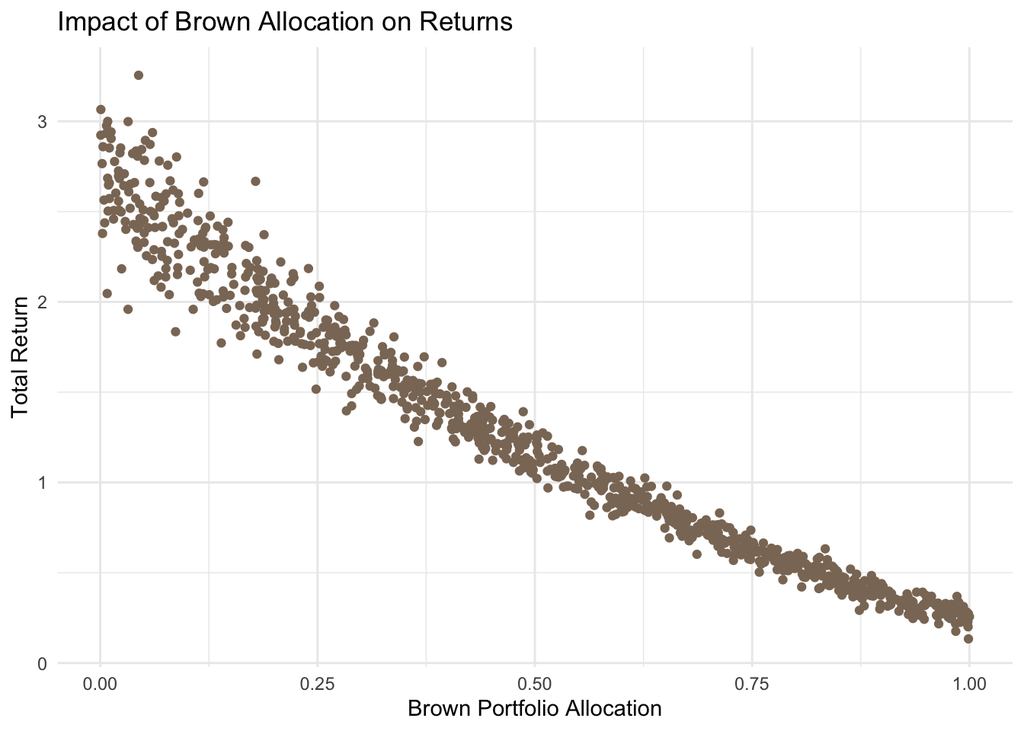

```r
# Plot total return vs. brown portfolio allocation
brown_plot <- ggplot(results, aes(x = brown_allocation, y = total_return)) +
  geom_point(color = "peachpuff4") +
  labs(
    title = "Impact of Brown Allocation on Returns",
    x = "Brown Portfolio Allocation",
    y = "Total Return"
  ) +
  theme_minimal()

brown_plot
```

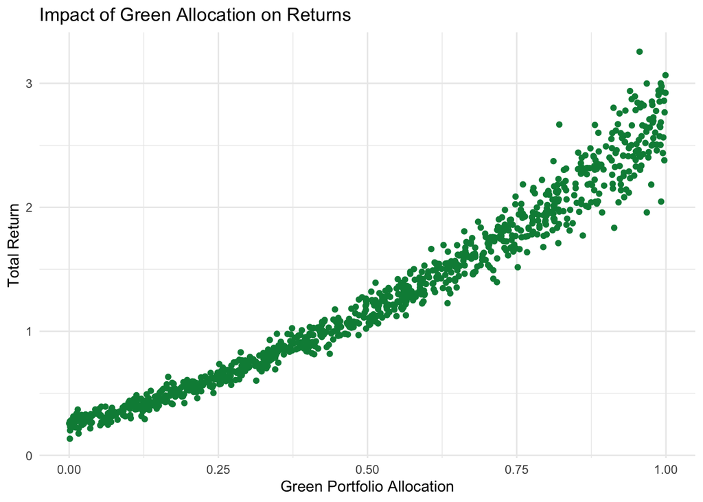

```r
# Plot total return vs. green portfolio allocation
green_plot <- ggplot(results, aes(x = green_allocation, y = total_return)) +
  geom_point(color = "springgreen4") +
  # geom_smooth(sd = FALSE) +
  labs(
    title = "Impact of Green Allocation on Returns",
    x = "Green Portfolio Allocation",
        # y = NULL) +  # Remove y-axis label
    y = "Total Return") +
  theme_minimal()

green_plot
```

Some sort of environmental aspect: Use an emissions factor to estimate average CO₂ emissions per dollar invested in different sectors

```r
# calculate_environmental_cost <- function(brown_allocation,
#                                          green_allocation,
#                                          # Define parameters that won't change
#                                          initial_investment = 10000,
#                                          emissions_factor_brown = 0.001,
#                                          emissions_factor_green = 0.0003,
#                                          SCC = 185) {
#
#   # Calculate emissions
#   brown_emissions <- initial_investment * brown_allocation * emissions_factor_brown
#   green_emissions <- initial_investment * green_allocation * emissions_factor_green
#
#   # Total emissions and environmental cost
#   total_emissions <- brown_emissions + green_emissions
#   environmental_cost <- total_emissions * SCC
#
#   return(environmental_cost)
# }
#
#
# # Example usage of the function
# brown_allocation <- 0
# green_allocation <- 1
#
# environmental_cost <- calculate_environmental_cost(brown_allocation, green_allocation)
# print(environmental_cost)
```

^^^^ this didnt work how I wanted it to

```r
# Parameters for environmental impact (amended code from above)
SCC <- 185  # Social Cost of Carbon in USD per tonne (this could be updated as needed)
emissions_factor_brown <- 0.001  # Emissions factor for brown investments: tonnes CO₂ per dollar invested
emissions_factor_green <- 0.0003  # Emissions factor for green investments: tonnes CO₂ per dollar invested

# Initialize data frame for storing results w/ environmental impacts
results <- data.frame(
  scenario = integer(),
  brown_allocation = numeric(),
  green_allocation = numeric(),
  final_value = numeric(),
  total_return = numeric(),
  brown_emissions = numeric(),
  green_emissions = numeric(),
  total_emissions = numeric(),
  environmental_cost = numeric()
)

#run the scenarios
for (i in 1:n_scenarios) {

#randomly allocate a portion to brown and the rest to green
  brown_allocation <- runif(1, 0, 1)  # Random allocation between 0 and 1
  green_allocation <- 1 - brown_allocation

#generate monthly returns for each portfolio type
  brown_monthly_returns <- rnorm(n_months, brown_avg_return / 12, brown_sd)
  green_monthly_returns <- rnorm(n_months, green_avg_return / 12, green_sd)

#initialize portfolio value
  portfolio_value <- initial_investment
  for (j in 1:n_months) {
    # Update portfolio value with weighted returns for the month
    monthly_return <- (brown_monthly_returns[j] * brown_allocation) +
                      (green_monthly_returns[j] * green_allocation)
    portfolio_value <- portfolio_value * (1 + monthly_return)
  }

#calculate cumulative return
  total_return <- (portfolio_value - initial_investment) / initial_investment

#calculate emissions based on allocation
  brown_emissions <- initial_investment * brown_allocation * emissions_factor_brown
  green_emissions <- initial_investment * green_allocation * emissions_factor_green
  total_emissions <- brown_emissions + green_emissions

#calculate environmental cost (social cost of carbon)
  environmental_cost <- total_emissions * SCC

#update results data frame
  results <- rbind(results, data.frame(
    scenario = i,
    brown_allocation = brown_allocation,
    green_allocation = green_allocation,
    final_value = portfolio_value,
    total_return = total_return,
    brown_emissions = brown_emissions,
    green_emissions = green_emissions,
    total_emissions = total_emissions,
    environmental_cost = environmental_cost
  ))
}

#results
summary(results)
```

```
    scenario      brown_allocation   green_allocation     final_value
 Min.   :   1.0   Min.   :0.001286   Min.   :0.0001906   Min.   :11740
 1st Qu.: 250.8   1st Qu.:0.268598   1st Qu.:0.2539171   1st Qu.:16299
 Median : 500.5   Median :0.510837   Median :0.4891635   Median :21208
 Mean   : 500.5   Mean   :0.507879   Mean   :0.4921209   Mean   :22289
 3rd Qu.: 750.2   3rd Qu.:0.746083   3rd Qu.:0.7314019   3rd Qu.:27539
 Max.   :1000.0   Max.   :0.999809   Max.   :0.9987138   Max.   :40979
  total_return    brown_emissions   green_emissions     total_emissions
 Min.   :0.1740   Min.   :0.01286   Min.   :0.0005718   Min.   :3.009
 1st Qu.:0.6299   1st Qu.:2.68598   1st Qu.:0.7617512   1st Qu.:4.880
 Median :1.1208   Median :5.10837   Median :1.4674905   Median :6.576
 Mean   :1.2289   Mean   :5.07879   Mean   :1.4763628   Mean   :6.555
 3rd Qu.:1.7539   3rd Qu.:7.46083   3rd Qu.:2.1942057   3rd Qu.:8.223
 Max.   :3.0979   Max.   :9.99809   Max.   :2.9961414   Max.   :9.999
 environmental_cost
 Min.   : 556.7
 1st Qu.: 902.8
 Median :1216.5
 Mean   :1212.7
 3rd Qu.:1521.2
 Max.   :1849.8
```

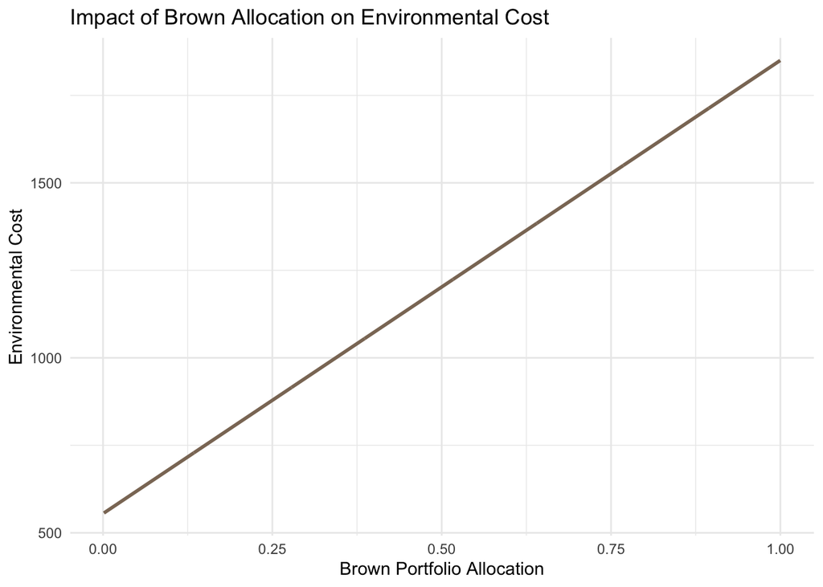

```r
#plot it
brown_environmental_cost_plot <- ggplot(results, aes(x = brown_allocation, y = environmental_cost)) +
  geom_line(color = "peachpuff4", size = 1) +  # Use a line instead of points
  labs(
    title = "Impact of Brown Allocation on Environmental Cost",
    x = "Brown Portfolio Allocation",
    y = "Environmental Cost"
  ) +
  theme_minimal()

brown_environmental_cost_plot
```

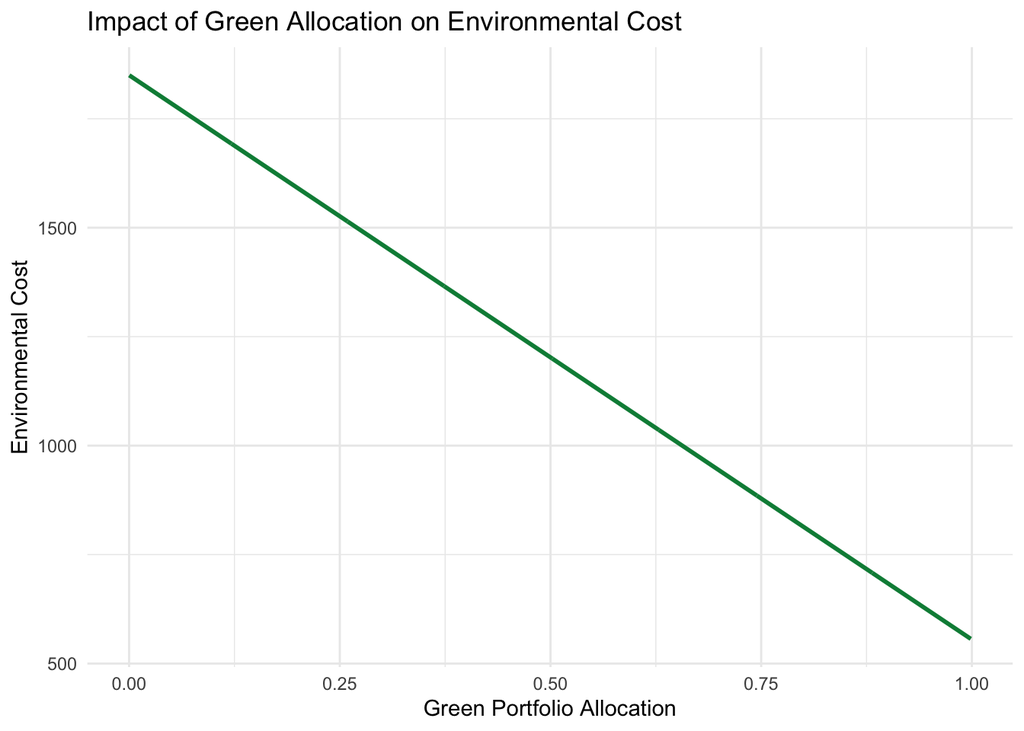

```r
green_environmental_cost_plot <- ggplot(results, aes(x = green_allocation, y = environmental_cost)) +
  geom_line(color = "springgreen4", size = 1) +  # Use a line instead of points
  labs(
    title = "Impact of Green Allocation on Environmental Cost",
    x = "Green Portfolio Allocation",
    y = "Environmental Cost"
  ) +
  theme_minimal()

green_environmental_cost_plot
```

- 1. Sector-Specific Emissions factor Data

  Many organizations and studies provide emissions intensity data by sector, measured in tonnes of CO₂ per unit of revenue, production, or value invested. High-emissions sectors typically include energy (especially fossil fuels), utilities, materials, and transportation, while green sectors often include renewable energy, technology with low environmental impact, and environmentally-focused industries.

  You could use emissions intensity data to estimate average CO₂ emissions per dollar invested in different sectors:

  The International Energy Agency (IEA) and Environmental Protection Agency (EPA) publish sectoral emissions intensity data.

  Carbon Disclosure Project (CDP) and Sustainalytics also provide emissions reports, often aggregated by sector.
- Large companies, especially public companies, publish **annual sustainability or ESG reports** with data on their total CO₂ emissions (Scope 1, 2, and sometimes 3 emissions).
- To find emissions per dollar invested, take the company’s total emissions and divide it by its market capitalization or revenue.
- For example, if a company in the energy sector emits 10 million tonnes of CO₂ annually and has a market cap of $100 billion, you might calculate an approximate emissions rate of 100,000,000,000dollars/10,000,000tonnes=0.0001tonnes CO₂ per dollar invested.